# Can search trends predict infectious disease?

Bob Turner

21 January 2018

*This is very much an exploration of some data - the endpoint is not a validated model. However, it offers some interesting prospects!*

I’ve recently been [hacking about notifications of infectious disease open government data](https://bobturneruk.github.io/Year_In_Disease.nb.html) and doing some plotting and [app building](https://bobturner.shinyapps.io/Year_in_Disease_Shiny/). I had an idea that it might be possible to predict the number of notifications from the amount of search interest in a disease - if there’s an outbreak, maybe people start Googling it? So I set about obtaining the necessary data and exploring this…

The first thing to do was load in the 53 weeks of infectious disease notifications data frame I [prepared in an earlier example](https://bobturneruk.github.io/Year_In_Disease.nb.html).

```r
wsndt<-readRDS("wsndt.Rda")
```

Next, I produced a list of diseases, with a bit of reformatting to replace “.” symbols in the source data with spaces. And then we will use this list to search [Google Trends](https://trends.google.com/trends/) over the same period of weeks as our original data, for the UK only, saving the results (as this set of queries takes a few minutes to run). This yielded data on realtively how much search interest there was in each disese (e.g. Scarlet Fever) over a 53 week period. Google normalises this.

```r
library(gtrendsR)
library(magrittr)
list_of_disease_terms<-gsub("\\.", " ", levels(wsndt$Disease)) #Generate list of diseases
trends<-data.frame()
timestring<-paste(min(wsndt$Date),max(wsndt$Date)) #Determine start and end dates for searches
for(disease in list_of_disease_terms){
  disease_trend <- gtrends(disease, geo = "GB", gprop = "web", time = timestring)$interest_over_time
  if(!is.null(disease_trend)){
    trends<-rbind(trends,disease_trend)
  }
}
trends<-trends[c("date","hits","keyword")] #Drop columns I don't want
names(trends)<-c("Date","Hits","Disease") #Choose the names I want for the columns
trends$Disease<-gsub(" ","\\.", trends$Disease) #Put the "." symbols back into disease names
trends$Date<-as.Date(trends$Date)
saveRDS(trends,"trends.Rda")
```

The next move was to merge the infectious disease notifications and the search data together into a single data frame, so I could make comparisons between search interest (hits) and reported cases.

```r
wsndt_m<-data.frame(Date=wsndt$Date,Disease=wsndt$Disease,value=wsndt$Number.Of.Cases,variable="Cases")
trends_m<-data.frame(Date=trends$Date,Disease=trends$Disease,value=trends$Hits,variable="Hits")
merged<-rbind(trends_m,wsndt_m)
```

Next, I plot hits versus time and cases versus time against each other for each disease. This is in no way a “dashboard” visualisation for an end user! However, it allows me to quickly eyeball all of the data and plot my next move…

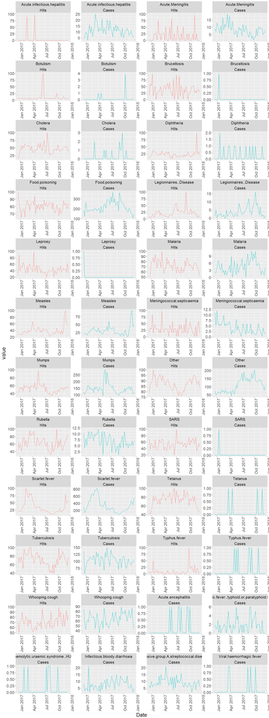

```r
library(ggplot2)
ggplot(merged, aes(x=Date, y=value, colour=variable))+
  geom_line()+
  facet_wrap(Disease~variable, ncol=4, scales = "free")+
  guides(colour=FALSE)+
  theme(text = element_text(size=20), axis.text.x = element_text(angle = 90, hjust = 1))
```

Data source: Google Trends (www.google.com/trends). Contains public sector information licensed under the Open Government Licence v3.0.

Looking at the charts, I think that there is a possible correlation between search interest and infectious disease notifications in at least a few instances. So next, I changed the shape of the data frame to facilitate making scatter plots of search interest versus infectious disease notifications.

```r
library(reshape2)
merged_wide<-dcast(merged,Date+Disease~variable)
```

To the plots I added a linear regression line (with 95% confidence intervals). Once again, this was to help me swiftly eyeball all of the data and see if correlations were likely to be present.

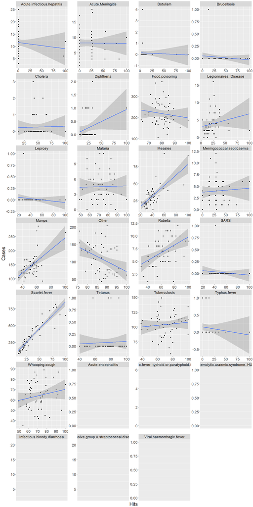

```r
library(ggplot2)
ggplot(merged_wide, aes(x=Hits, y=Cases))+
  geom_point()+
  facet_wrap(~Disease, ncol=4, scales="free")+
  geom_smooth(method='lm')+
  theme(text = element_text(size=20))
```

Data source: Google Trends (www.google.com/trends). Contains public sector information licensed under the Open Government Licence v3.0. NB for some search terms, no data is returned by Google, so that’s why there are blank plots.

Again, we see some diseases that appear to have a model-able relationship between search interest and notifications. Although it’s also clear that most don’t! So finally, I determined the [Pearson correlation coefficients](https://en.wikipedia.org/wiki/Pearson_correlation_coefficient) for each disease and plotted the results in order of coefficient value.

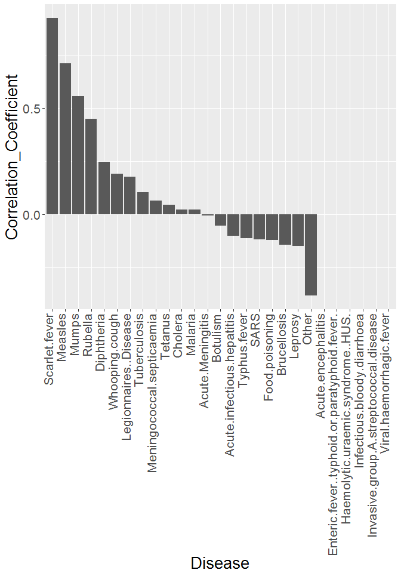

```r
library(dplyr)
cor_coef<-group_by(merged_wide,Disease) %>%
          summarise(Correlation_Coefficient = cor(Hits,Cases), Number_Of_Cases=sum(Cases))

cor_coef$Disease <- factor(cor_coef$Disease,
                           levels = cor_coef$Disease[order(cor_coef$Correlation_Coefficient,decreasing = TRUE)])
ggplot(cor_coef, aes(Disease, Correlation_Coefficient))+
  geom_col()+
  theme(text = element_text(size=20), axis.text.x = element_text(angle = 90, hjust = 1, vjust = 0))
```

Data source: Google Trends (www.google.com/trends). Contains public sector information licensed under the Open Government Licence v3.0.

That said, glancing back at the scatter plots, scarlet fever, measles and mumps have relationships between search interest and and reported cases that look promising. And whilst there would be work to do to validate that intuition, I think this helps make the general point that it would be possible to build models to predict other valuable data from Google Trends.

See my [website](https://sites.google.com/view/robert-turner) for more examples. Contact me on bob dot turner dot uk at gmail dot com with comments or questions.